# Analysis of Seven Seconds or Less in the NBA

5/27/2020

# Introduction to 7 Seconds or Less

- Pioneered by Mike D’Antoni while at the Phoenix Suns (now with Houston Rockets) in 2004
- The Suns went from a 28-54 record in 2003, to 62-20 the next season
- The strategy:
  - More field goals attempted leads to more field goals made
  - The goal was to get a shot up in less than 7 seconds for every offensive possession
  - Often criticized because of the lack of concentration on the defensive end
- In short, the offense is focused on three areas:
  - High volume three point shooting
  - High percentage two point shots from within the painted area
  - Minimize opportunities for turnovers

[figure not shown]

# Regarding 3-Point Efficiency

- Initial theory was that a high volume of 3P attempts (alone) would increase win percentage.
  - It turns out, there needs to be a level of efficiency to go along with the high attempt rate.
- 38% appears to be the magical efficiency rating
  - Remember, 3PA is important too!
  - There’s a big difference between shooting 4/10 (12 points) from three, versus shooting 12/30 (36 points)
- Incidentally, it turns out that because of the increased win percentage, chances of making the playoffs also improve

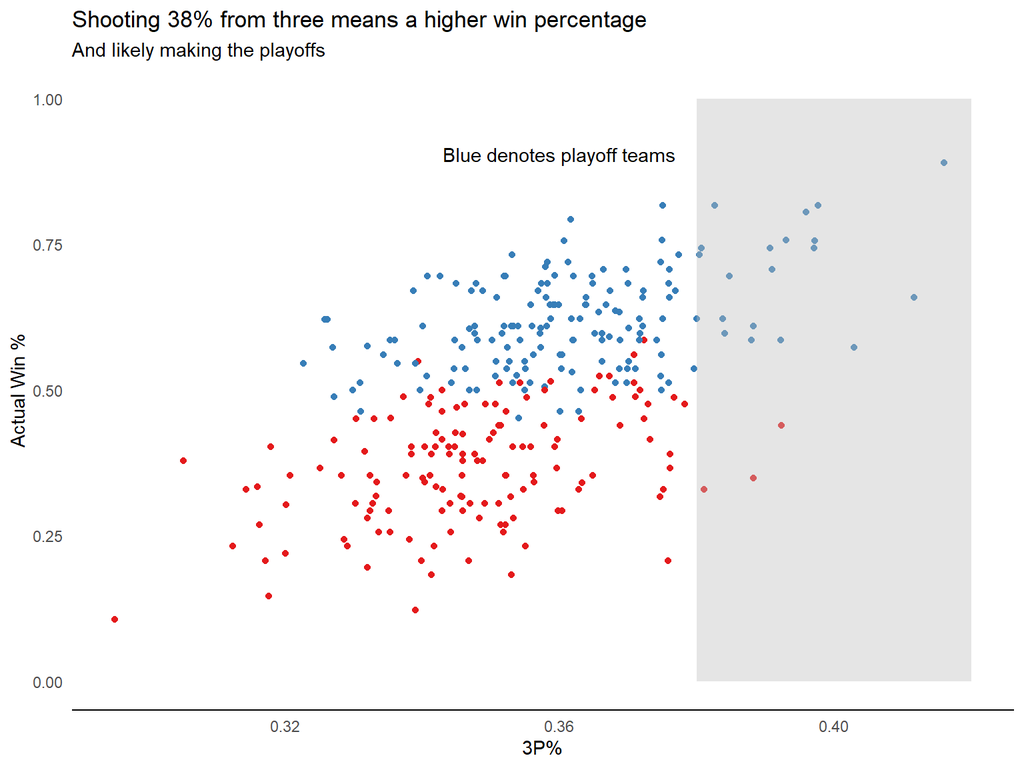

# Data Suggests Limiting Two-Point Attempts

- Teams should only be attempting a maximum of 61 2P shots per game over the course of a season
- Take less, make more
  - A team’s goal should be to take less 2P, but make them with high efficiency
  - This is what the Suns and Rockets have done with D’Antoni as their coach
  - Take less 2P, but when one is taken, make sure it’s a high percentage shot
- Take the previous example:
  - To score 36 points on 40% shooting from three takes 30 possessions
  - To score 36 points on 40% shooting from two takes 45 possessions (+15)!

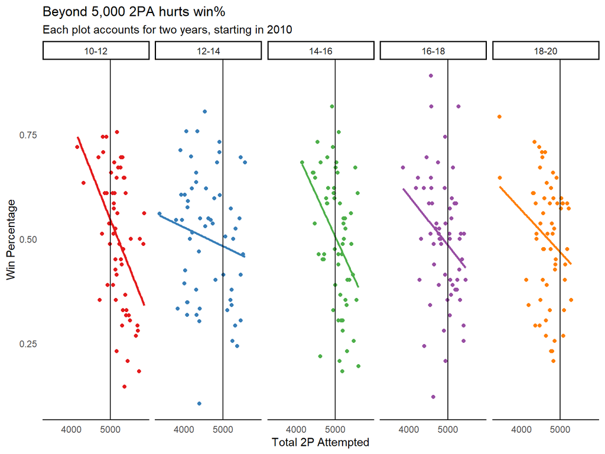

# Wrap-Up

- The 7 Seconds or Less philosophy has been incredibly effective in the past two decades
- Much of the strategy correlates to a higher win percentage
- Suggestions to NBA front offices, coaches, and players:
  - Take more threes, while maintaining a 38% success rate
  - Take less twos, but make them at a more frequent rate